# Wine Quality Red

```
## wine$quality: 3
##    Min. 1st Qu.  Median    Mean 3rd Qu.    Max.
##  0.9947  0.9961  0.9976  0.9975  0.9988  1.0008
## --------------------------------------------------------
## wine$quality: 4
##    Min. 1st Qu.  Median    Mean 3rd Qu.    Max.
##  0.9934  0.9957  0.9965  0.9965  0.9974  1.0010
## --------------------------------------------------------
## wine$quality: 5
##    Min. 1st Qu.  Median    Mean 3rd Qu.    Max.
##  0.9926  0.9962  0.9970  0.9971  0.9979  1.0031
## --------------------------------------------------------
## wine$quality: 6
##    Min. 1st Qu.  Median    Mean 3rd Qu.    Max.
##  0.9901  0.9954  0.9966  0.9966  0.9979  1.0037
## --------------------------------------------------------
## wine$quality: 7
##    Min. 1st Qu.  Median    Mean 3rd Qu.    Max.
##  0.9906  0.9948  0.9958  0.9961  0.9974  1.0032
## --------------------------------------------------------
## wine$quality: 8
##    Min. 1st Qu.  Median    Mean 3rd Qu.    Max.
##  0.9908  0.9942  0.9949  0.9952  0.9972  0.9988
```

There is a negative correlation between quality and density, though from quality=4 to quality=5 the box plot medians go against the correlation direction.

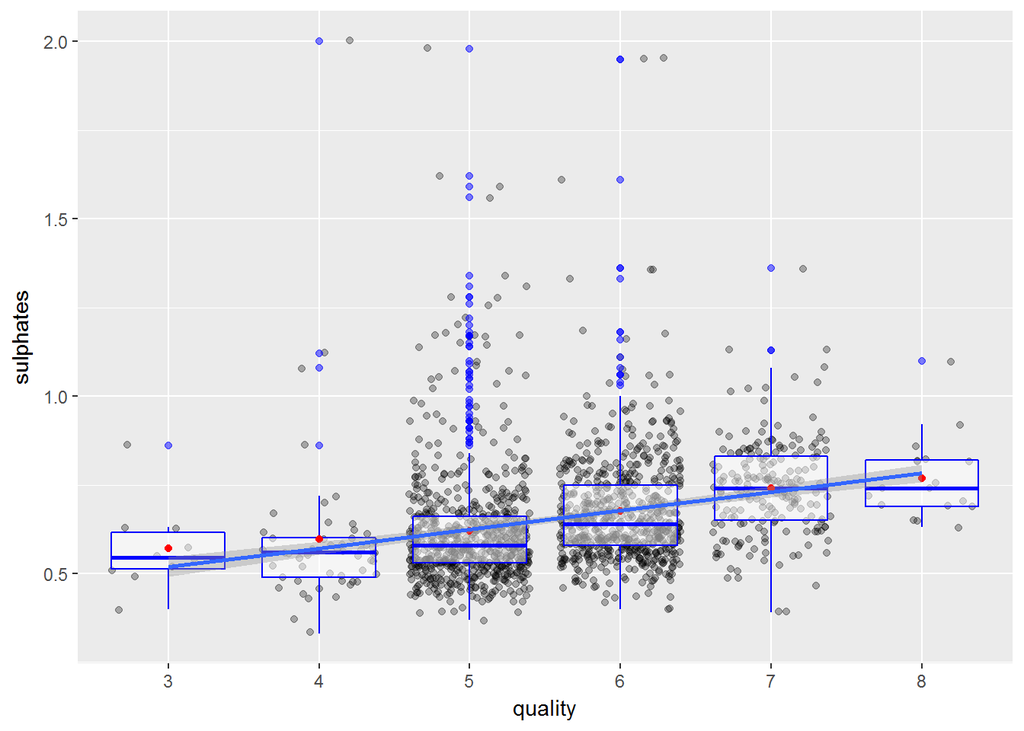

```
## wine$quality: 3
##    Min. 1st Qu.  Median    Mean 3rd Qu.    Max.
##  0.4000  0.5125  0.5450  0.5700  0.6150  0.8600
## --------------------------------------------------------
## wine$quality: 4
##    Min. 1st Qu.  Median    Mean 3rd Qu.    Max.
##  0.3300  0.4900  0.5600  0.5964  0.6000  2.0000
## --------------------------------------------------------
## wine$quality: 5
##    Min. 1st Qu.  Median    Mean 3rd Qu.    Max.
##   0.370   0.530   0.580   0.621   0.660   1.980
## --------------------------------------------------------
## wine$quality: 6
##    Min. 1st Qu.  Median    Mean 3rd Qu.    Max.
##  0.4000  0.5800  0.6400  0.6753  0.7500  1.9500
## --------------------------------------------------------
## wine$quality: 7
##    Min. 1st Qu.  Median    Mean 3rd Qu.    Max.
##  0.3900  0.6500  0.7400  0.7413  0.8300  1.3600
## --------------------------------------------------------
## wine$quality: 8
##    Min. 1st Qu.  Median    Mean 3rd Qu.    Max.
##  0.6300  0.6900  0.7400  0.7678  0.8200  1.1000
```

Sulphates increase with wine quality.

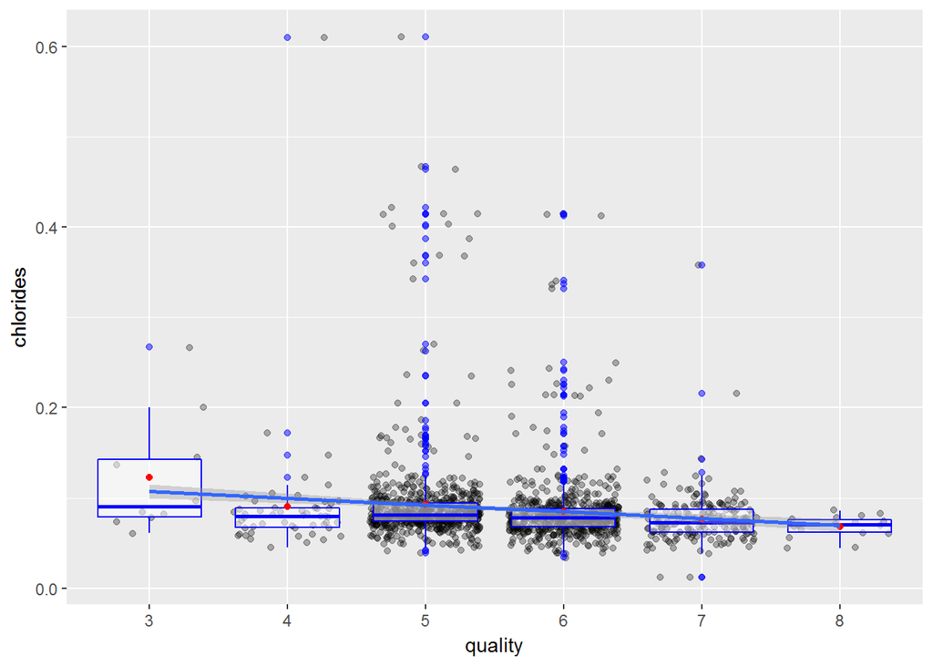

```
## wine$quality: 3
##    Min. 1st Qu.  Median    Mean 3rd Qu.    Max.
##  0.0610  0.0790  0.0905  0.1225  0.1430  0.2670
## --------------------------------------------------------
## wine$quality: 4
##    Min. 1st Qu.  Median    Mean 3rd Qu.    Max.
## 0.04500 0.06700 0.08000 0.09068 0.08900 0.61000
## --------------------------------------------------------
## wine$quality: 5
##    Min. 1st Qu.  Median    Mean 3rd Qu.    Max.
## 0.03900 0.07400 0.08100 0.09274 0.09400 0.61100
## --------------------------------------------------------
## wine$quality: 6
##    Min. 1st Qu.  Median    Mean 3rd Qu.    Max.
## 0.03400 0.06825 0.07800 0.08496 0.08800 0.41500
## --------------------------------------------------------
## wine$quality: 7
##    Min. 1st Qu.  Median    Mean 3rd Qu.    Max.
## 0.01200 0.06200 0.07300 0.07659 0.08700 0.35800
## --------------------------------------------------------
## wine$quality: 8
##    Min. 1st Qu.  Median    Mean 3rd Qu.    Max.
## 0.04400 0.06200 0.07050 0.06844 0.07550 0.08600
```

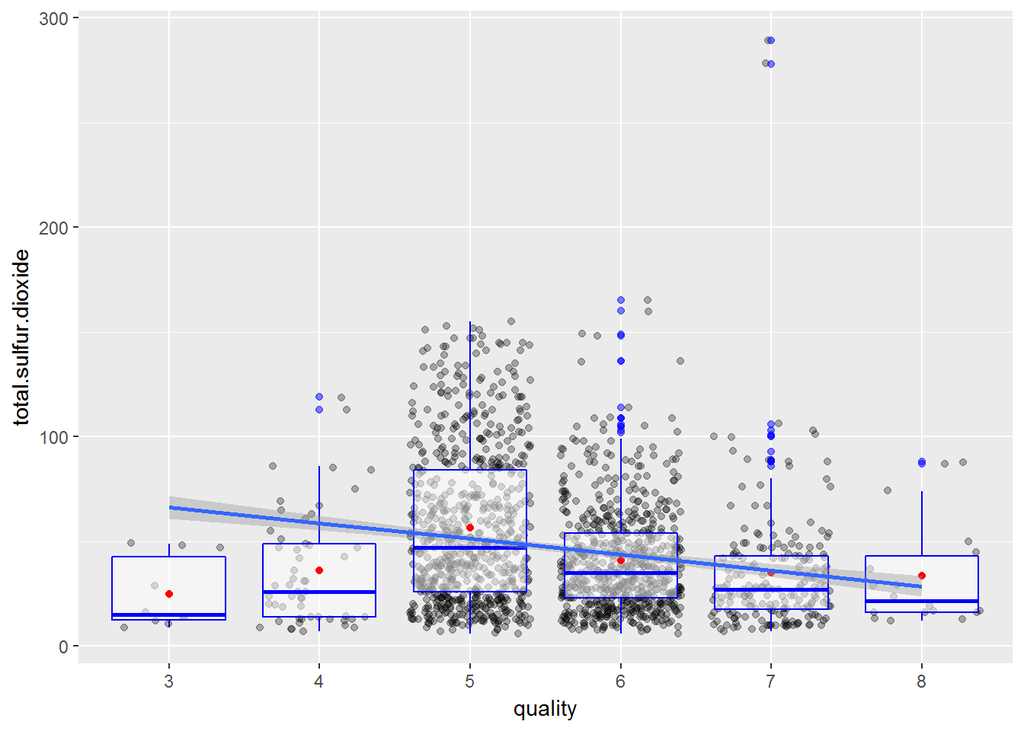

```
## wine$quality: 3
##    Min. 1st Qu.  Median    Mean 3rd Qu.    Max.
##     9.0    12.5    15.0    24.9    42.5    49.0
## --------------------------------------------------------
## wine$quality: 4
##    Min. 1st Qu.  Median    Mean 3rd Qu.    Max.
##    7.00   14.00   26.00   36.25   49.00  119.00
## --------------------------------------------------------
## wine$quality: 5
##    Min. 1st Qu.  Median    Mean 3rd Qu.    Max.
##    6.00   26.00   47.00   56.51   84.00  155.00
## --------------------------------------------------------
## wine$quality: 6
##    Min. 1st Qu.  Median    Mean 3rd Qu.    Max.
##    6.00   23.00   35.00   40.87   54.00  165.00
## --------------------------------------------------------
## wine$quality: 7
##    Min. 1st Qu.  Median    Mean 3rd Qu.    Max.
##    7.00   17.50   27.00   35.02   43.00  289.00
## --------------------------------------------------------
## wine$quality: 8
##    Min. 1st Qu.  Median    Mean 3rd Qu.    Max.
##   12.00   16.00   21.50   33.44   43.00   88.00
```

From quality=3 to quality=5, the correlation between quality and total sulfur dioxide is positive, but negative after quality=5. There is no single direction relation.

# Bivariate Analysis

### Talk about some of the relationships you observed in this part of the investigation. How did the feature(s) of interest vary with other features in the dataset?

There are strongest positive relationships between quality and fixed acidity, citric acid, sulphates and alcohol. Additionally, I found the opposite relationships between quality and volatile acidity, density and pH.

### Did you observe any interesting relationships between the other features (not the main feature(s) of interest)?

Yes, there are many variables with strong correlation. For example, free sulfur dioxide is strongly correlated with total sulfur dioxide as Free sulfur dioxide is subset of total sulfur dioxide.

### What was the strongest relationship you found?

Alcohol and quality have the strongest positive correlation, volatile acidity and quality have the strongest negative correlation.

# Multivariate Plots Section

Function for plotting multivariate scatterplots

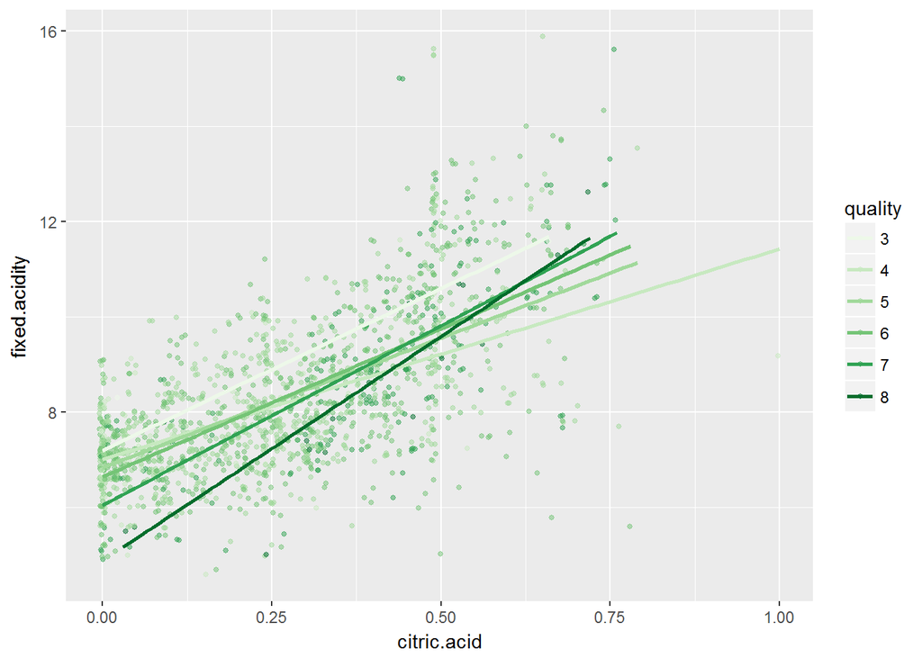

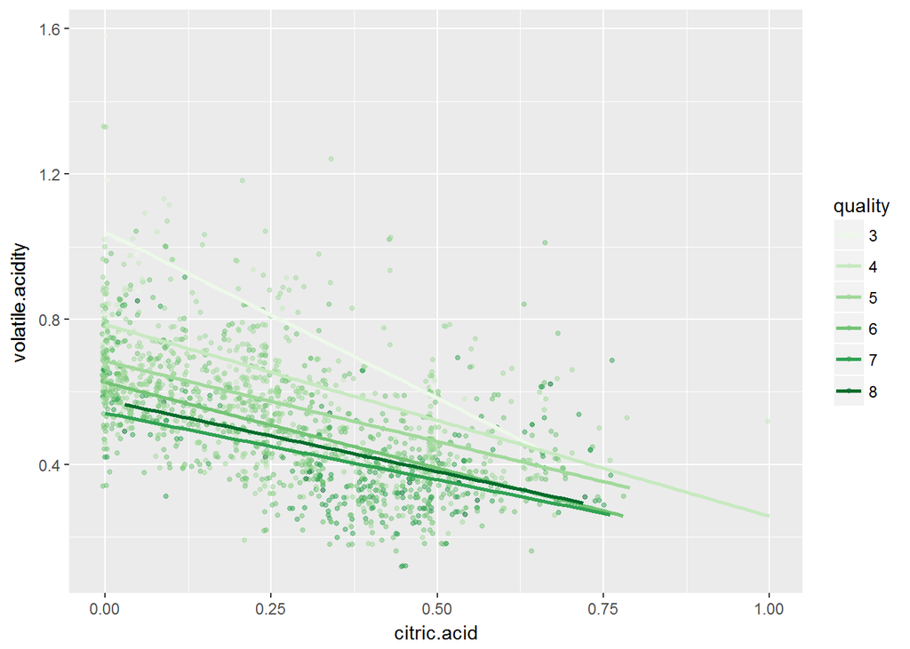

This scatter plot suggests that the highest grade wines tend to have relatively lower volatile acidity and relatively higher citric acid.

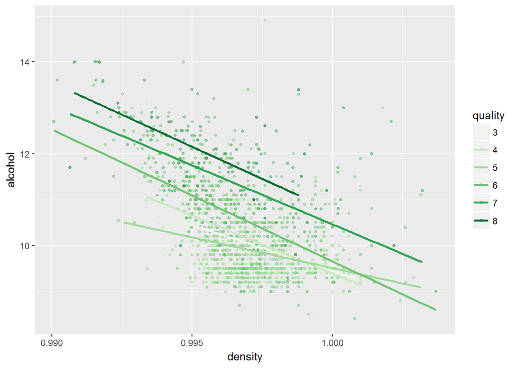

This scatter plot suggests that the highest grade wines tend to have relatively lower density and relatively higher alcohol.

[figure not shown]

This scatter plot suggests that the highest grade wines tend to have relatively higher citric acid and relatively higher sulphates.

# Multivariate Analysis

### Talk about some of the relationships you observed in this part of the investigation. Were there features that strengthened each other in terms of looking at your feature(s) of interest?

Citric acid, fixed acidity, volatile acidity, density, alcohol and sulphates are important for wine quality. High citric acid, fixed acidity, alcohol and sulphates combined with low volatile acidity and density seem to make better wines.

### Were there any interesting or surprising interactions between features?

I found that the density of the wine is almost less than 1, which may be due to alcohol density, because alcohol density is less than 1. But the higher the alcohol content, the higher the wine quality grade.

# Final Plots and Summary

### Plot One

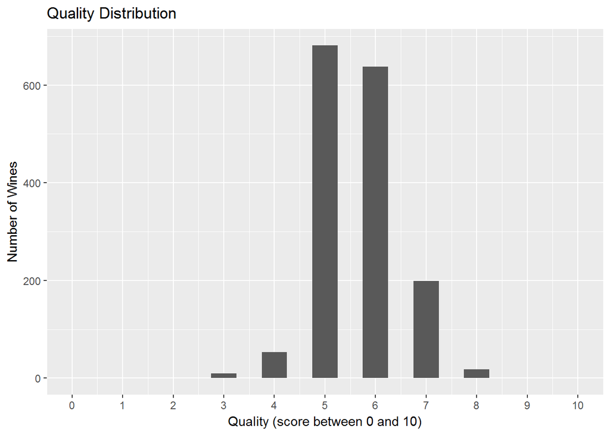

### Description One

This histogram gives quality distribution of red wines in the dataset, and all gather grade 3 to 8. The vast majority of wines are grade 5 and 6.

### Plot Two

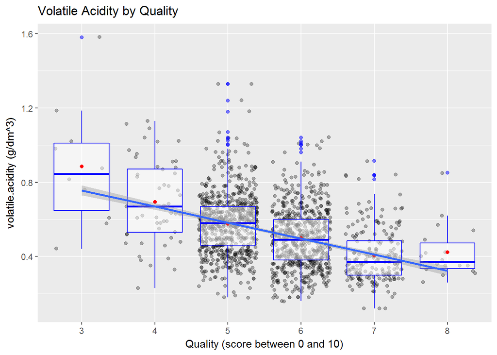

### Plot Three

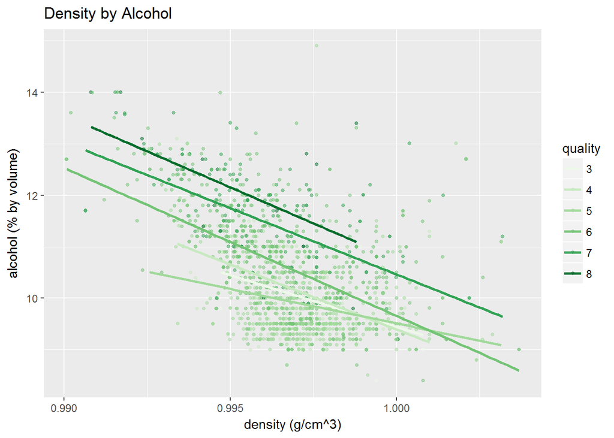

### Description Three

This scatter plot suggests that the highest grade wines tend to have relatively lower density and relatively higher alcohol.

# Reflection

Volatile acidity and alcohol have strongest correlation between the quality. But some variables have a close relationship with Volatile acidity and alcohol, just like citric acid and dencity which more or less will affect wine quality. So, I further explore the relationship between quality and them. Throughout the exploration process, I found that my application of histogram and box is still relatively skilled, but the function is very poor which makes a lot of repetitive code. So I need to strengthen it in the future. In addition, I found it better to display more information through layers than I use too single graph.

I think a further investigation of this dataset can predict a model that is used to estimate wine’s quality grade based on it’s chemical attributes. However, I think such a model is hard to predict accurately, because other data besides chemical features, such as grape types, wine brand might be important for quality predictions as well.